# Analysis of GTestimate’s impact on downstream results

# Introduction

In this report we want to highlight the impact of GTestimate on various downstream analysis tasks. Namely we ll look into UMAP, clustering and the expression of marker genes.

# pbmc3k

First lets analyse the popular pbmc3k dataset following Seurat guided clustering tutorial. We ll first download the data and create the Seurat object.

```r
#https://support.10xgenomics.com/single-cell-gene-expression/datasets/1.1.0/pbmc3k
download.file('https://cf.10xgenomics.com/samples/cell/pbmc3k/pbmc3k_filtered_gene_bc_matrices.tar.gz', str_glue('{folder}pbmc3k_data.tar.gz'))
untar(str_glue('{folder}pbmc3k_data.tar.gz'), exdir = str_glue('{folder}data'))

pbmc_seurat <- CreateSeuratObject(counts = Read10X(str_glue('{folder}data/filtered_gene_bc_matrices/hg19/')), min.cells = 3, min.features = 200)
pbmc_seurat[["percent.mt"]] <- PercentageFeatureSet(pbmc_seurat, pattern = "^MT-")

pbmc_seurat <- subset(pbmc_seurat, subset = nFeature_RNA > 200 & nFeature_RNA < 2500 & percent.mt < 5)
```

Next we ll perform the basic analysis pipeline following the tutorials suggestions. We ll also repeat the exact same analysis except we ll use GTestimate() instead of NormalizeData()

```r
pbmc_seurat_ML <- pbmc_seurat %>%
  NormalizeData %>%
  FindVariableFeatures %>%
  ScaleData %>%
  RunPCA(ndim = 10) %>%
  FindNeighbors(dims= 1:10) %>%
  FindClusters(resolution = 0.5) %>%
  RunUMAP(dims = 1:10)
```

```
## Modularity Optimizer version 1.3.0 by Ludo Waltman and Nees Jan van Eck
##
## Number of nodes: 2638
## Number of edges: 95927
##
## Running Louvain algorithm...
## Maximum modularity in 10 random starts: 0.8728
## Number of communities: 9
## Elapsed time: 0 seconds
```

```r
pbmc_seurat_GT <- pbmc_seurat %>%
  GTestimate %>%
  FindVariableFeatures %>%
  ScaleData %>%
  RunPCA(ndim = 10) %>%
  FindNeighbors(dims= 1:10) %>%
  FindClusters(resolution = 0.5) %>%
  RunUMAP(dims = 1:10)
```

```
## Modularity Optimizer version 1.3.0 by Ludo Waltman and Nees Jan van Eck
##
## Number of nodes: 2638
## Number of edges: 94490
##
## Running Louvain algorithm...
## Maximum modularity in 10 random starts: 0.8760
## Number of communities: 9
## Elapsed time: 0 seconds
```

```r
pbmc_seurat_SC <- pbmc_seurat %>%
  SCTransform %>%
  RunPCA(ndim = 10) %>%
  FindNeighbors(dims= 1:10) %>%
  FindClusters(resolution = 0.5) %>%
  RunUMAP(dims = 1:10)
```

```
## Modularity Optimizer version 1.3.0 by Ludo Waltman and Nees Jan van Eck
##
## Number of nodes: 2638
## Number of edges: 88620
##
## Running Louvain algorithm...
## Maximum modularity in 10 random starts: 0.8921
## Number of communities: 10
## Elapsed time: 0 seconds
```

```r
NKG7_expression_tbl <- tibble(log_expression = GetAssayData(pbmc_seurat_ML, assay = 'RNA', layer = 'data')['NKG7',], method = 'NormalizeData')
NKG7_expression_tbl <- NKG7_expression_tbl %>% rbind(tibble(log_expression = GetAssayData(pbmc_seurat_GT, assay = 'GTestimate', layer = 'data')['NKG7',], method = 'GTestimate'))
NKG7_expression_tbl <- NKG7_expression_tbl %>% rbind(tibble(log_expression = GetAssayData(pbmc_seurat_SC, assay = 'SCT', layer = 'data')['NKG7',], method = 'SCTransform'))
```

SCTransform completely changes the scale of the log-expression values and is therefore not comparable:

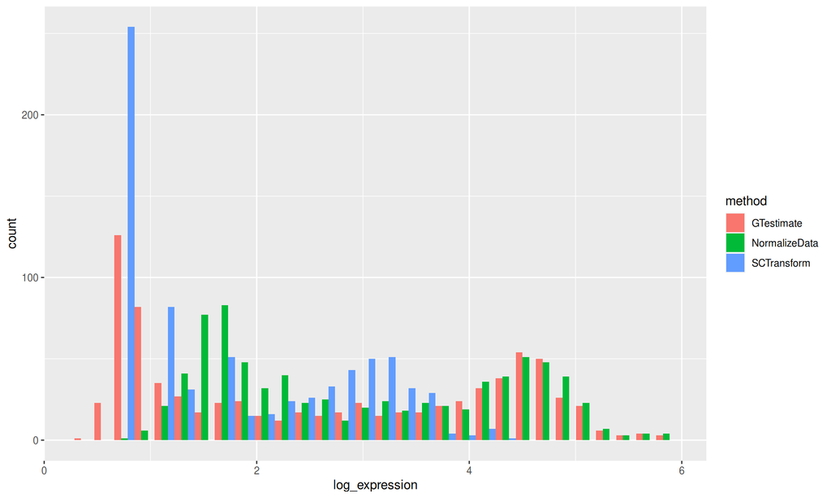

```r
expression_scale_plot <- ggplot(NKG7_expression_tbl %>% filter(log_expression != 0), aes(x = log_expression, fill = method)) + geom_histogram(position = 'dodge')

expression_scale_plot
```

```r
ggsave(filename = str_glue('{folder}expression_scale_plot.png'), expression_scale_plot, width = 7, height = 3.5)
saveRDS(file = str_glue('{folder}expression_scale_plot.Rds'), expression_scale_plot)
```

Next we can annotate the clusters and look at the resulting UMAPs:

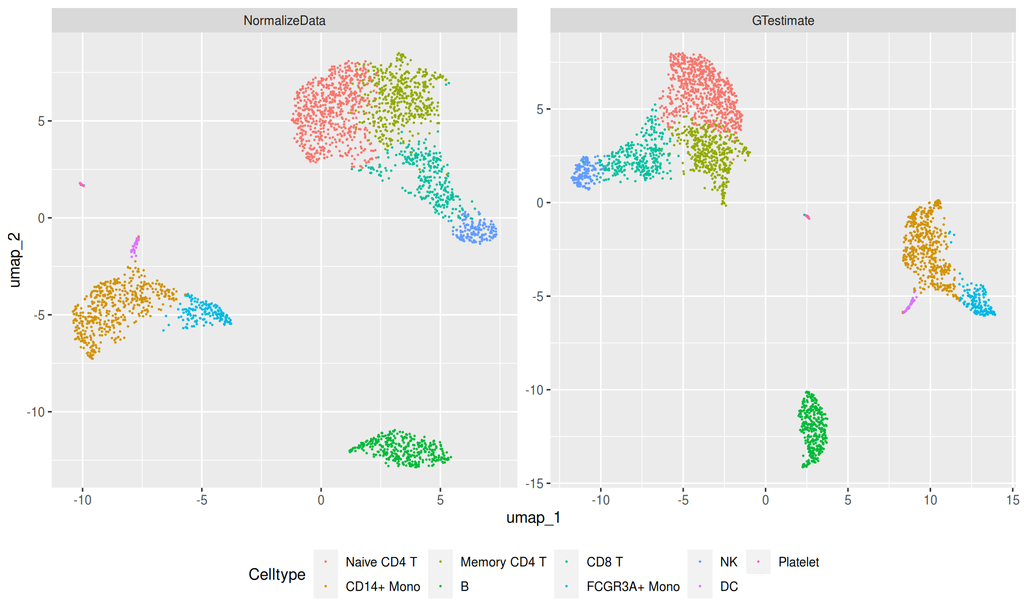

```r
new.cluster.ids <- c("Naive CD4 T", "CD14+ Mono", "Memory CD4 T", "B", "CD8 T", "FCGR3A+ Mono",
    "NK", "DC", "Platelet")
names(new.cluster.ids) <- levels(pbmc_seurat_ML)
pbmc_seurat_ML <- RenameIdents(pbmc_seurat_ML, new.cluster.ids)
pbmc_seurat_GT <- RenameIdents(pbmc_seurat_GT, new.cluster.ids)

umap_seurat_ML <- Embeddings(pbmc_seurat_ML, reduction = 'umap') %>%
  as.data.frame %>%
  rownames_to_column(var = 'Cell') %>%
  as_tibble %>%
  cbind(`Celltype` = Idents(pbmc_seurat_ML)) %>%
  mutate(Method = 'NormalizeData')

umap_seurat_GT <- Embeddings(pbmc_seurat_GT, reduction = 'umap') %>%
  as.data.frame %>%
  rownames_to_column(var = 'Cell') %>%
  as_tibble %>%
  cbind(`Celltype` = Idents(pbmc_seurat_GT)) %>%
  mutate(Method = 'GTestimate')

umap_combined <- rbind(umap_seurat_ML, umap_seurat_GT) %>% mutate(Method = factor(Method, levels = c('NormalizeData', 'GTestimate')))

pbmc_umap <- ggplot(umap_combined) + geom_point(aes(x = umap_1, y = umap_2, col = Celltype), size = umap_dot_size) + facet_wrap(~Method, scales = 'free') + theme(legend.position = 'bottom')# + geom_text_repel(data = umap_combined %>% group_by(Celltype, Method) %>% summarise(umap_1 = mean(umap_1), umap_2 = mean(umap_2)), aes(x = umap_1, y = umap_2, label = Celltype), point.size = NA,  max.overlaps = 100)

pbmc_umap
```

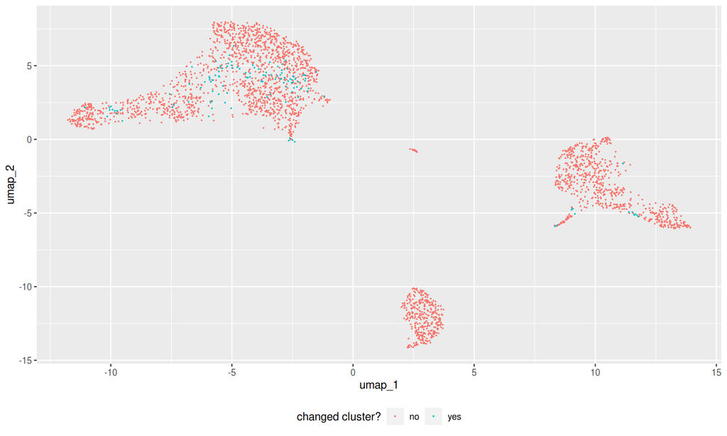

```r
ggsave(filename = str_glue('{folder}pbmc_umap_clusters.png'), pbmc_umap, width = 6.6, height = 4)
saveRDS(file = str_glue('{folder}pbmc_umap_clusters.Rds'), pbmc_umap)

umap_combined_differences <- Embeddings(pbmc_seurat_GT, reduction = 'umap') %>%
  as.data.frame %>%
  rownames_to_column(var = 'Cell') %>%
  as_tibble %>%
  cbind(`Celltype_GT` = Idents(pbmc_seurat_GT), `Celltype_ML` = Idents(pbmc_seurat_ML)) %>%
  mutate(`changed cluster` = Celltype_GT != Celltype_ML) %>%
  mutate(`changed cluster?` = replace(`changed cluster`, `changed cluster` == F, 'no')) %>%
  mutate(`changed cluster?` = replace(`changed cluster?`, `changed cluster` == T, 'yes')) %>%
  mutate(`changed cluster?` = factor(`changed cluster?`, levels = c('yes', 'no')))

umap_identity <- ggplot() +
  geom_point(data = umap_combined_differences %>% filter(`changed cluster` == F),
             aes(x = umap_1, y = umap_2, col = `changed cluster?`), size = umap_dot_size) +
  geom_point(data = umap_combined_differences %>% filter(`changed cluster` == T),
             aes(x = umap_1, y = umap_2, col = `changed cluster?`), size = umap_dot_size) +
  theme(legend.position = 'bottom')

umap_identity
```

```r
ggsave(filename = str_glue('{folder}pbmc_umap_identity.png'), umap_identity, width = 3.4, height = 3.5)
saveRDS(file = str_glue('{folder}pbmc_umap_identity.Rds'), umap_identity)

precent_change_ident <- sum(umap_combined_differences$`changed cluster`)/length(umap_combined_differences$`changed cluster`)*100
```

4.6247157 % of cells changed cell-type identity when clustered after GTestimate() instead of NormalizeData().

To show how the normalized expression of individual genes changed we can visualize the expression of some celltype specific genes in the different clusters.

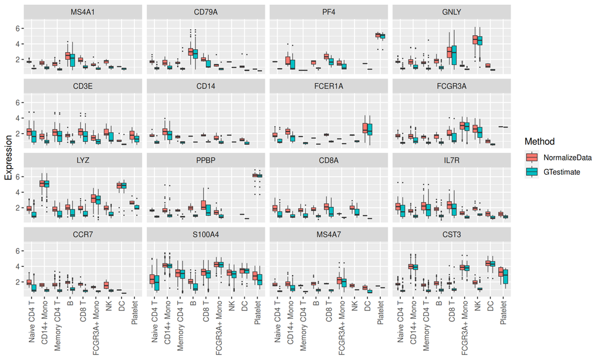

```r
marker_genes <- c("MS4A1", "CD79A", "PF4", "GNLY", "CD3E", "CD14", "FCER1A", "FCGR3A", "LYZ", "PPBP", "CD8A", "IL7R", "CCR7", "S100A4", "MS4A7", "CST3", "NKG7")

marker_tbl_ML <- GetAssayData(pbmc_seurat_ML, assay = 'RNA', slot = 'data')[marker_genes,] %>%
  as.matrix() %>%
  t %>%
  as.data.frame() %>%
  rownames_to_column(var = 'Cell') %>%
  as_tibble() %>%
  cbind(Celltype = Idents(pbmc_seurat_ML), nCount = pbmc_seurat_ML$nCount_RNA) %>%
  mutate(Method = 'NormalizeData') %>%
  pivot_longer(all_of(marker_genes), values_to = 'Expression', names_to = 'Gene') %>%
  filter(Expression != 0)

marker_tbl_GT <- GetAssayData(pbmc_seurat_GT, assay = 'GTestimate', slot = 'data')[marker_genes,] %>%
  as.matrix() %>%
  t %>%
  as.data.frame() %>%
  rownames_to_column(var = 'Cell') %>%
  as_tibble() %>%
  cbind(Celltype = Idents(pbmc_seurat_GT), nCount = pbmc_seurat_GT$nCount_RNA) %>%
  mutate(Method = 'GTestimate') %>%
  pivot_longer(all_of(marker_genes), values_to = 'Expression', names_to = 'Gene') %>%
  filter(Expression != 0)

marker_tbl_combined <- rbind(marker_tbl_ML, marker_tbl_GT) %>% mutate(Method = factor(Method, levels = c('NormalizeData', 'GTestimate')))

marker_tbl_combined_2 <- marker_tbl_combined %>%
  mutate(Gene = factor(Gene, levels = marker_genes)) %>%
  filter(Gene != 'NKG7')


more_markers_plot <- ggplot(marker_tbl_combined_2) + geom_boxplot(aes(x = Celltype, y = Expression, fill = Method), outlier.size = .3, outlier.stroke = .3, linewidth = .3) + facet_wrap(~Gene) + theme(axis.text.x = element_text(angle = 90, vjust = 0.5, hjust = 1), axis.title.x = element_blank())

more_markers_plot
```

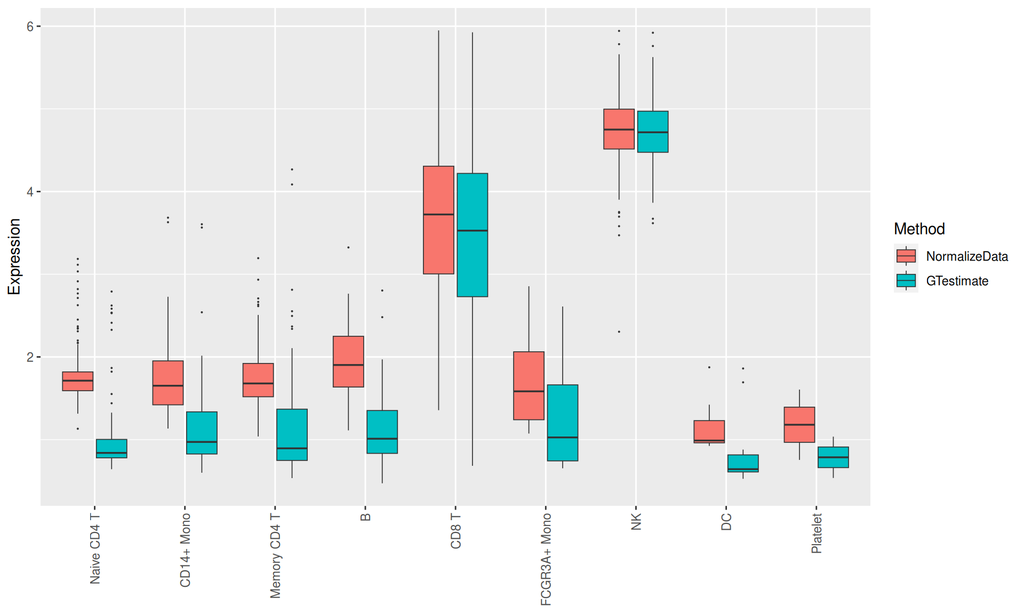

```r
ggsave(filename = str_glue('{folder}more_markers_plot.png'), more_markers_plot, width = 4, height = 2)
saveRDS(file = str_glue('{folder}more_markers_plot.Rds'), more_markers_plot)

nkg7_plot <- ggplot(marker_tbl_combined %>% filter(Gene == 'NKG7')) +
  geom_boxplot(aes(x = Celltype, y = Expression, fill = Method), outlier.size = .3, outlier.stroke = .3, linewidth = .3) +
  theme(axis.text.x = element_text(angle = 90, vjust = 0.5, hjust = 1), axis.title.x = element_blank())

nkg7_plot
```

```r
ggsave(filename = str_glue('{folder}nkg7_plot.png'), nkg7_plot, width = 4, height = 2)
saveRDS(file = str_glue('{folder}nkg7_plot.Rds'), nkg7_plot)
```

We can also make a scatter-plot comparing the estimates of NormalizeData() and GTestimate() for an example gene:

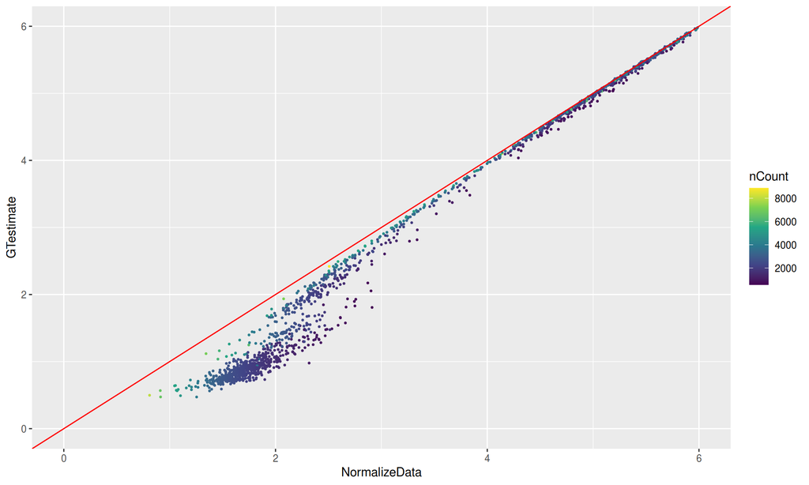

```r
scatter_tbl <- marker_tbl_combined %>%
  filter(Gene == 'LYZ') %>%
  pivot_wider(values_from = Expression, names_from = Method)

lyz_scatter_pbmc <- ggplot(scatter_tbl) +
  geom_point(aes(x = NormalizeData, y = GTestimate, col = nCount), size = 0.5) +
  geom_abline(slope = 1, col = 'red') +
  scale_x_continuous(limits = c(0,6)) +
  scale_y_continuous(limits = c(0,6)) +
  scale_color_viridis_c()

lyz_scatter_pbmc
```

```r
ggsave(filename = str_glue('{folder}lyz_scatter_pbmc.pdf'), lyz_scatter_pbmc, width = 3.4, height = 3.5)
saveRDS(file = str_glue('{folder}lyz_scatter_pbmc.Rds'), lyz_scatter_pbmc)
```

# Developing Pancreas

Since the pbmc3k data-set has pretty well defined cell-types we will next analyse a data-set with more continuous cell-type changes. For this we chose the popular pancreas development data-set endocrinogenesis_day15, which is often used as an example in RNA-velocity approaches.

Here we ll download and import the data:

```r
dir_create(str_glue('{folder}data'))
download.file('https://github.com/theislab/scvelo_notebooks/raw/master/data/Pancreas/endocrinogenesis_day15.h5ad', destfile = str_glue('{folder}data/endocrinogenesis_day15.h5ad'))

adata <- anndata::read_h5ad(str_glue('{folder}data/endocrinogenesis_day15.h5ad'))

pancreas_seurat <- CreateSeuratObject(t(as.matrix(adata$X)), assay = "RNA")
pancreas_seurat <- AddMetaData(pancreas_seurat, adata$obs)
```

Next we perform some basic Seurat based clustering using both NormalizeData() and GTestimate() to construct two different UMAPs:

```r
pancreas_seurat_ML <- pancreas_seurat %>%
  NormalizeData() %>%
  FindVariableFeatures() %>%
  ScaleData() %>%
  RunPCA(ndim = 50) %>%
  FindNeighbors(dims = 1:50) %>%
  FindClusters(resolution = 0.4) %>%
  RunUMAP(dims = 1:50)
```

```
## Modularity Optimizer version 1.3.0 by Ludo Waltman and Nees Jan van Eck
##
## Number of nodes: 3696
## Number of edges: 178645
##
## Running Louvain algorithm...
## Maximum modularity in 10 random starts: 0.8916
## Number of communities: 8
## Elapsed time: 0 seconds
```

```r
pancreas_seurat_GT <- pancreas_seurat %>%
  GTestimate() %>%
  FindVariableFeatures() %>%
  ScaleData() %>%
  RunPCA(ndim = 50) %>%
  FindNeighbors(dims = 1:50) %>%
  FindClusters(resolution = 0.4) %>%
  RunUMAP(dims = 1:50)
```

```
## Modularity Optimizer version 1.3.0 by Ludo Waltman and Nees Jan van Eck
##
## Number of nodes: 3696
## Number of edges: 172863
##
## Running Louvain algorithm...
## Maximum modularity in 10 random starts: 0.8910
## Number of communities: 8
## Elapsed time: 0 seconds
```

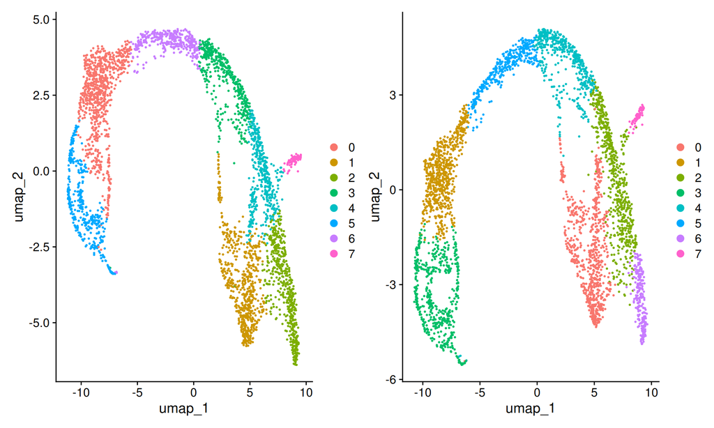

```r
DimPlot(pancreas_seurat_ML) + DimPlot(pancreas_seurat_GT, reduction = 'umap')
```

We can visualize the resulting clusters on the umap:

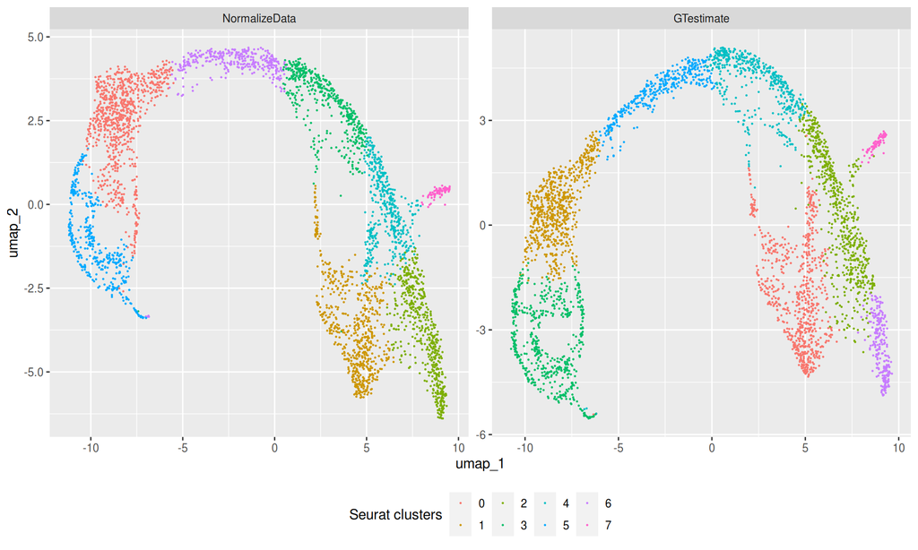

```r
pancreas_umap_seurat_ML <- Embeddings(pancreas_seurat_ML, reduction = 'umap') %>%
  as.data.frame %>%
  rownames_to_column(var = 'Cell') %>%
  as_tibble %>%
  cbind(`Seurat clusters` = pancreas_seurat_ML$seurat_clusters,
        Clusters = pancreas_seurat_ML$clusters,
        Coarse_Clusters = pancreas_seurat_ML$clusters_coarse) %>%
  mutate(Method = 'NormalizeData')

pancreas_umap_seurat_GT <- Embeddings(pancreas_seurat_GT, reduction = 'umap') %>%
  as.data.frame %>%
  rownames_to_column(var = 'Cell') %>%
  as_tibble %>%
  cbind(`Seurat clusters` = pancreas_seurat_GT$seurat_clusters,
        Clusters = pancreas_seurat_GT$clusters,
        Coarse_Clusters = pancreas_seurat_GT$clusters_coarse) %>%
  mutate(Method = 'GTestimate')

pancreas_umap_combined <- rbind(pancreas_umap_seurat_ML, pancreas_umap_seurat_GT) %>% mutate(Method = factor(Method, levels = c('NormalizeData', 'GTestimate')))

pancreas_umap <- ggplot(pancreas_umap_combined) + geom_point(aes(x = umap_1, y = umap_2, col = `Seurat clusters`), size = umap_dot_size) + facet_wrap(~Method, scales = 'free') + theme(legend.position = 'bottom')
pancreas_umap_ML <- ggplot(pancreas_umap_combined %>% filter(Method == 'NormalizeData')) + geom_point(aes(x = umap_1, y = umap_2, col = `Seurat clusters`), size = umap_dot_size) + theme(legend.position = 'bottom')
pancreas_umap_GT <- ggplot(pancreas_umap_combined %>% filter(Method == 'GTestimate')) + geom_point(aes(x = umap_1, y = umap_2, col = `Seurat clusters`), size = umap_dot_size) + theme(legend.position = 'bottom')

ggsave(filename = str_glue('{folder}pancreas_umap_ML.png'), pancreas_umap_ML, width = 3.4, height = 3)
saveRDS(file = str_glue('{folder}pancreas_umap_ML.Rds'), pancreas_umap_ML)

ggsave(filename = str_glue('{folder}pancreas_umap_GT.png'), pancreas_umap_GT, width = 3.4, height = 3)
saveRDS(file = str_glue('{folder}pancreas_umap_GT.Rds'), pancreas_umap_GT)

pancreas_umap
```

```r
ggsave(filename = str_glue('{folder}pancreas_umap.png'), pancreas_umap, width = 3.4, height = 3)
saveRDS(file = str_glue('{folder}pancreas_umap.Rds'), pancreas_umap)
```

Importantly, this clustering is different from the cluster annotation in the original data-set. The original clustering and annotation was performed on a larger data-set while this is only a subset.

This subset results in different clusters. The original clustering shown on our UMAP would look like this:

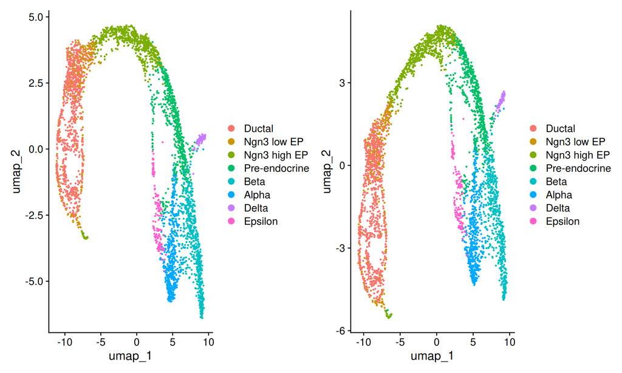

```r
Idents(pancreas_seurat_GT) <- pancreas_seurat_GT$clusters
Idents(pancreas_seurat_ML) <- pancreas_seurat_ML$clusters

DimPlot(pancreas_seurat_ML) + DimPlot(pancreas_seurat_GT)
```

And we can again highlight the cells which changed clustering between NormalizeData and GTestimate:

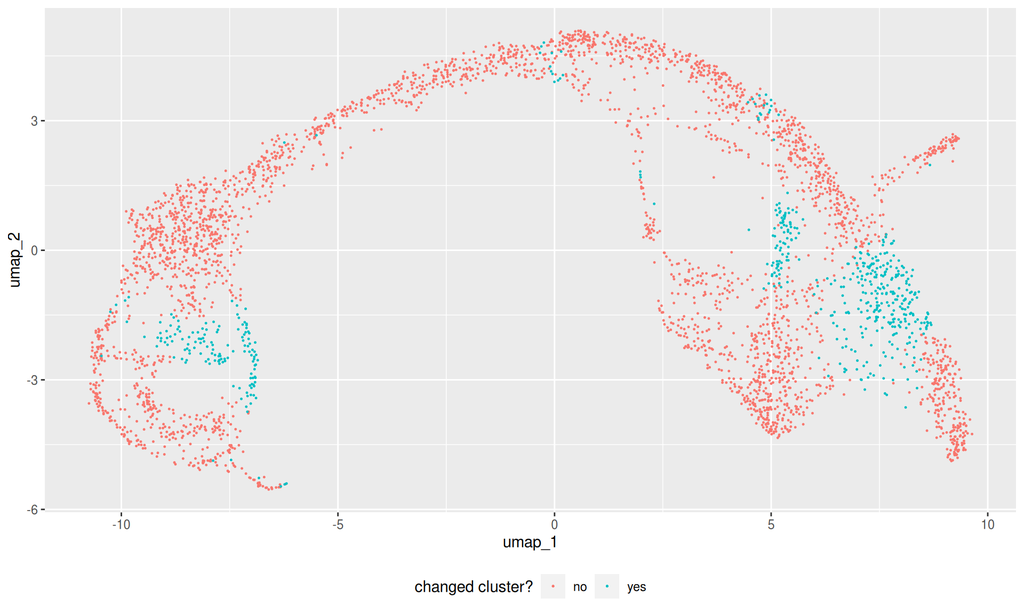

```r
Idents(pancreas_seurat_GT) <- pancreas_seurat_GT$seurat_clusters
Idents(pancreas_seurat_ML) <- pancreas_seurat_ML$seurat_clusters

umap_combined_differences_pancreas <- Embeddings(pancreas_seurat_GT, reduction = 'umap') %>%
  as.data.frame %>%
  rownames_to_column(var = 'Cell') %>%
  as_tibble %>%
  cbind(`Celltype_ML` = fct_recode(Idents(pancreas_seurat_ML), cluster_1 = '5', cluster_2 = '0', cluster_3 = '6', cluster_4 = '3', cluster_5 = '4', cluster_6 = '7', cluster_7 = '1', cluster_8 = '2'), `Celltype_GT` = fct_recode(Idents(pancreas_seurat_GT), cluster_1 = '3', cluster_2 = '1', cluster_3 = '5', cluster_4 = '4', cluster_5 = '2', cluster_6 = '7', cluster_7 = '0', cluster_8 = '6')) %>%
  mutate(`changed cluster` = Celltype_GT != Celltype_ML) %>%
  mutate(`changed cluster?` = replace(`changed cluster`, `changed cluster` == F, 'no')) %>%
  mutate(`changed cluster?` = replace(`changed cluster?`, `changed cluster` == T, 'yes')) %>%
  mutate(`changed cluster?` = factor(`changed cluster?`, levels = c('yes', 'no')))

umap_identity_pancreas <- ggplot() +
  geom_point(data = umap_combined_differences_pancreas %>% filter(`changed cluster` == F),
             aes(x = umap_1, y = umap_2, col = `changed cluster?`), size = 0.2) +
  geom_point(data = umap_combined_differences_pancreas %>% filter(`changed cluster` == T),
             aes(x = umap_1, y = umap_2, col = `changed cluster?`), size = 0.2) +
  theme(legend.position = 'bottom')

umap_identity_pancreas
```

```r
ggsave(filename = str_glue('{folder}pancreas_umap_identity.png'), umap_identity_pancreas, width = 3.4, height = 3.5)
saveRDS(file = str_glue('{folder}pancreas_umap_identity.Rds'), umap_identity_pancreas)

precent_change_ident_pancreas <- sum(umap_combined_differences_pancreas$`changed cluster`)/length(umap_combined_differences_pancreas$`changed cluster`)*100
```

14.8809524 % of cells changed cell-type identity when clustered after GTestimate() instead of NormalizeData().

We will also show the changes in clustering using a Sankey diagram:

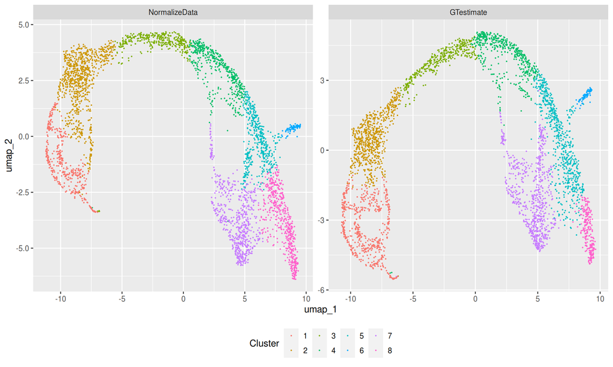

```r
pancreas_umap_combined <- pancreas_umap_combined %>%
  cbind(Cluster = c(fct_recode(Idents(pancreas_seurat_ML), `1` = '5', `2` = '0', `3` = '6', `4` = '3', `5` = '4', `6` = '7', `7` = '1', `8` = '2'), fct_recode(Idents(pancreas_seurat_GT), `1` = '3', `2` = '1', `3` = '5', `4` = '4', `5` = '2', `6` = '7', `7` = '0', `8` = '6'))) %>%
  as_tibble() %>%
  mutate(Cluster = factor(Cluster, levels = 1:8))

pancreas_umap_same_clusters <- ggplot(pancreas_umap_combined) + geom_point(aes(x = umap_1, y = umap_2, col = Cluster), size = umap_dot_size) + facet_wrap(~Method, scales = 'free') + theme(legend.position = 'bottom')
pancreas_umap_ML_same_clusters <- ggplot(pancreas_umap_combined %>% filter(Method == 'NormalizeData')) + geom_point(aes(x = umap_1, y = umap_2, col = Cluster), size = umap_dot_size) + theme(legend.position = 'bottom')
pancreas_umap_GT_same_clusters <- ggplot(pancreas_umap_combined %>% filter(Method == 'GTestimate')) + geom_point(aes(x = umap_1, y = umap_2, col = Cluster), size = umap_dot_size) + theme(legend.position = 'bottom')

ggsave(filename = str_glue('{folder}pancreas_umap_ML_same_clusters.png'), pancreas_umap_ML_same_clusters, width = 3.4, height = 3)
saveRDS(file = str_glue('{folder}pancreas_umap_ML_same_clusters.Rds'), pancreas_umap_ML_same_clusters)

ggsave(filename = str_glue('{folder}pancreas_umap_GT_same_clusters.png'), pancreas_umap_GT_same_clusters, width = 3.4, height = 3)
saveRDS(file = str_glue('{folder}pancreas_umap_GT_same_clusters.Rds'), pancreas_umap_GT_same_clusters)

ggsave(filename = str_glue('{folder}pancreas_umap_same_clusters.png'), pancreas_umap_same_clusters, width = 3.4, height = 3)
saveRDS(file = str_glue('{folder}pancreas_umap_same_clusters.Rds'), pancreas_umap_same_clusters)

pancreas_umap_same_clusters
```

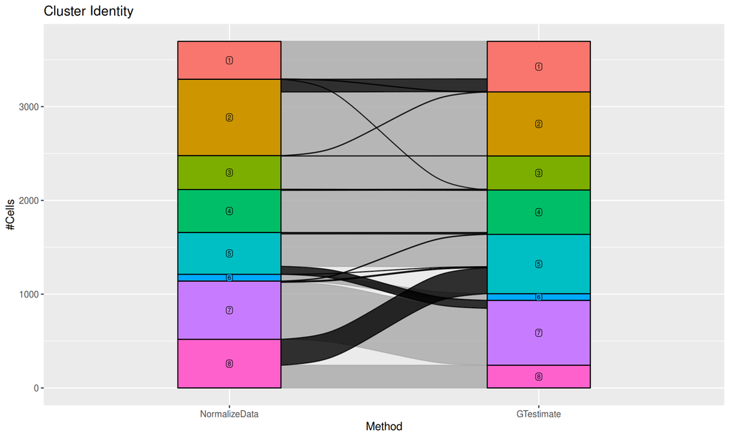

```r
pancreas_alluvial <- pancreas_umap_combined %>%
  select(Cell, Method, Cluster) %>%
  pivot_wider(values_from = Cluster, names_from = Method) %>%
  group_by(NormalizeData, GTestimate) %>%
  summarize(`#Cells` = n()) %>%
  mutate(changed_ident = NormalizeData != GTestimate) %>%
  pivot_longer(c(NormalizeData, GTestimate), names_to = 'Method', values_to = 'Cluster') %>%
  group_by(Method) %>%
  mutate(group = row_number(), Cluster = factor(Cluster, levels = 1:8), Method = factor(Method, levels = c('NormalizeData','GTestimate')))

cluster_flow_plot <- ggplot(pancreas_alluvial) +
  geom_flow(alpha = .8, aes(x = Method, stratum = Cluster, alluvium = group, y = `#Cells`, fill = changed_ident, col = changed_ident)) +
  scale_color_manual(values = c('darkgrey', 'black')) +
  geom_stratum(alpha = 1, aes(x = Method, stratum = Cluster, alluvium = group, y = `#Cells`, fill = Cluster)) +
  scale_fill_manual(values = c(gg_color_hue(8), 'darkgrey', 'black')) +
  geom_label(stat = "stratum", aes(x = Method, stratum = Cluster, alluvium = group, y = `#Cells`, label = Cluster, fill = Cluster), label.padding = unit(0.05, "cm"), size = 6/.pt) +
  theme(legend.position = 'none') +
  ggtitle('Cluster Identity')

cluster_flow_plot
```

```r
ggsave(filename = str_glue('{folder}cluster_flow_plot.png'), cluster_flow_plot, width = 3.4, height = 3)
saveRDS(file = str_glue('{folder}cluster_flow_plot.Rds'), cluster_flow_plot)
```